# R Notebook

Marc-André Désautels

7 novembre 2017

# Introduction

Ceci est un document `notebook` en [R Markdown](http://rmarkdown.rstudio.com). Lorsque vous éxécutez du code à l’intérieur du `notebook`, les résultats apparaissent sous le code.

Essayez d’éxécuter le bloc de code ci-dessous en cliquant le bouton *Run* (il est représenté par une flèche verte pointant vers la droite) ou alors en plaçant votre curseur dans le bloc et en tapant *Ctrl+Shift+Enter*.

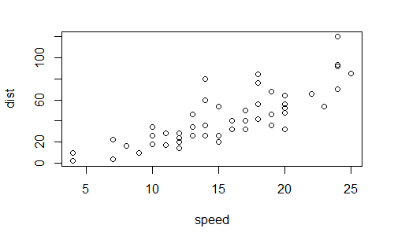

```r
plot(cars)
```

Pour ajouter un nouveau bloc de code, vous appuyez sur le bouton *Insert* ou alors vous appuyez sur *Ctrl+Alt+I*.

# Utilisation des données

Lorsque des données sont intialisées dans `R`, vous pouvez les visualiser avec la commande `View`. De plus, si les données sont des `tibbles` (un type précis de base de données), vous obtenez un résumé des données en tapant le nom.

```r
diamonds
```

| carat | cut | color | clarity | depth | table | price | x | y | z |
| --- | --- | --- | --- | --- | --- | --- | --- | --- | --- |
| 0.23 | Ideal | E | SI2 | 61.5 | 55.0 | 326 | 3.95 | 3.98 | 2.43 |
| 0.21 | Premium | E | SI1 | 59.8 | 61.0 | 326 | 3.89 | 3.84 | 2.31 |
| 0.23 | Good | E | VS1 | 56.9 | 65.0 | 327 | 4.05 | 4.07 | 2.31 |
| 0.29 | Premium | I | VS2 | 62.4 | 58.0 | 334 | 4.20 | 4.23 | 2.63 |
| 0.31 | Good | J | SI2 | 63.3 | 58.0 | 335 | 4.34 | 4.35 | 2.75 |
| 0.24 | Very Good | J | VVS2 | 62.8 | 57.0 | 336 | 3.94 | 3.96 | 2.48 |
| 0.24 | Very Good | I | VVS1 | 62.3 | 57.0 | 336 | 3.95 | 3.98 | 2.47 |
| 0.26 | Very Good | H | SI1 | 61.9 | 55.0 | 337 | 4.07 | 4.11 | 2.53 |
| 0.22 | Fair | E | VS2 | 65.1 | 61.0 | 337 | 3.87 | 3.78 | 2.49 |
| 0.23 | Very Good | H | VS1 | 59.4 | 61.0 | 338 | 4.00 | 4.05 | 2.39 |

[output cut: 990 more lines]

Vous pouvez accéder à une variable en particulier en utilisant l’opérateur `$`. Pour ne pas encombrer l’écran, nous allons observer les 100 premières valeurs de la variable `cut`.

```r
diamonds$cut[1:100]
```

```
  [1] Ideal     Premium   Good      Premium   Good
  [6] Very Good Very Good Very Good Fair      Very Good
 [11] Good      Ideal     Premium   Ideal     Premium
 [16] Premium   Ideal     Good      Good      Very Good
 [21] Good      Very Good Very Good Very Good Very Good
 [26] Very Good Premium   Very Good Very Good Very Good
 [31] Very Good Very Good Very Good Very Good Very Good
 [36] Good      Good      Good      Very Good Ideal
 [41] Ideal     Ideal     Good      Good      Good
 [46] Premium   Very Good Good      Very Good Very Good
 [51] Very Good Ideal     Ideal     Premium   Premium
 [56] Ideal     Premium   Very Good Very Good Good
 [61] Ideal     Premium   Ideal     Ideal     Premium
 [66] Ideal     Ideal     Very Good Premium   Premium
 [71] Very Good Very Good Premium   Premium   Good
 [76] Very Good Very Good Very Good Very Good Very Good
 [81] Very Good Very Good Ideal     Ideal     Good
 [86] Premium   Premium   Premium   Premium   Premium
 [91] Ideal     Fair      Ideal     Very Good Very Good
 [96] Good      Good      Fair      Very Good Premium
5 Levels: Fair < Good < Very Good < ... < Ideal
```

# Statistiques descriptives

## Mesures de tendance centrale

Nous pouvons calculer facilement la médiane (`median`) et la moyenne (`mean`) avec `R`.

```r
median(diamonds$carat)
```

```
[1] 0.7
```

```r
mean(diamonds$price)
```

```
[1] 3932.8
```

Pour calculer le mode, on peut utiliser la fonction `table` qui regoupe les unités ayant les mêmes modalités ou valeurs ensemble.

```r
table(diamonds$cut)
```

```
     Fair      Good Very Good   Premium     Ideal
     1610      4906     12082     13791     21551
```

Le mode est donc *Ideal*.

## Les mesures de dispersion